# Loaded Joint Simon Effect

Working memory load on the joint Simon effect

cn

2022-04-14

```r
set.seed(12345) # for reproducibility

if (!require("pacman", quietly = TRUE)) install.packages("pacman")
pacman::p_load(tidyverse, psych, papaja, knitr) # data manipulation
pacman::p_load(afex, emmeans) # stats
pacman::p_load(cowplot, patchwork) # plot
pacman::p_load(permuco) # permutation
pacman::p_load(Superpower) # power analysis

options(dplyr.summarise.inform=FALSE)
options(knitr.kable.NA = '')
set_sum_contrasts() # see Singmann & Kellen (2020)

nsims <- 1e4
```

# 1 Task Comparison

아래 모든 과제에서 참가자는 화살표의 방향을 무시한 채로 색깔에 대해서만 반응한다. 가령, (A) 사이먼 과제에서 참가자는 화살표가 초록색이면 왼쪽 버튼을, 빨간색이면 오른쪽 버튼을 누른다. (B) Go/no-go 과제의 참가자는 화살표가 빨간색일 때에만 반응하고 초록색일 때는 반응하지 않아야 한다. (C) 결합 사이먼 과제에서 한 참가자는 초록색 화살표에 대해 go/no-go 과제를 하고, 다른 참가자는 빨간색 화살표에 대해 go/no-go 과제를 한다.

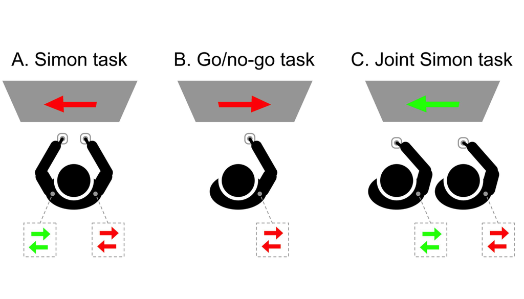

```r
ggdraw() + draw_image("figs/Fig1.jpg")
```

# 2 Pilot Experiment

[Sebanz 등(2003)](https://bit.ly/37DlJI1)이 보고한 효과를 재현하였다. 참가자는 **Solo** 구획에서는 과제를 혼자 수행하였고(Fig 1B), **Joint** 구획에서는 다른 참가자(실험자)와 함께 과제를 수행하였다(Fig 1C).

## 2.1 Data

전체 시행 중 참가자가 반응해야 하는 시행을 추출하여 분석하였다.

```r
E1 = read.csv('data/mergeJSEv1.csv', header = TRUE)
E1$sid <- factor(E1$sid)
E1$performer = factor(E1$performer, levels=c(1,2), labels=c("Solo","Joint"))
E1$compatibility = factor(E1$compatibility, levels=c(1,2),
                          labels=c("Compatible","Incompatible"))
E1$rt <- E1$rt*1000
str(E1)
## 'data.frame':    4800 obs. of  9 variables:
##  $ sid          : Factor w/ 10 levels "1","2","3","4",..: 1 1 1 1 1 1 1 1 1 1 ...
##  $ performer    : Factor w/ 2 levels "Solo","Joint": 1 1 1 1 1 1 1 1 1 1 ...
##  $ compatibility: Factor w/ 2 levels "Compatible","Incompatible": 2 1 2 2 1 1 2 1 2 1 ...
##  $ turn         : int  1 0 0 0 1 0 1 0 1 1 ...
##  $ dir          : int  1 1 2 2 2 1 1 1 1 2 ...
##  $ col          : int  1 2 2 2 1 2 1 2 1 1 ...
##  $ resp         : int  0 0 0 0 1 0 1 0 1 1 ...
##  $ corr         : int  0 1 1 1 1 1 1 1 1 1 ...
##  $ rt           : num  7000 7000 7000 7000 491 ...
headTail(E1)
##       sid performer compatibility turn dir col resp corr     rt
## 1       1      Solo  Incompatible    1   1   1    0    0   7000
## 2       1      Solo    Compatible    0   1   2    0    1   7000
## 3       1      Solo  Incompatible    0   2   2    0    1   7000
## 4       1      Solo  Incompatible    0   2   2    0    1   7000
## ...  <NA>      <NA>          <NA>  ... ... ...  ...  ...    ...
## 4797   10     Joint    Compatible    0   1   2    0    1   7000
## 4798   10     Joint    Compatible    1   2   1    1    1 447.23
## 4799   10     Joint  Incompatible    1   1   1    1    1 369.61
## 4800   10     Joint    Compatible    1   2   1    1    1 483.01

table(E1$sid)
##
##   1   2   3   4   5   6   7   8   9  10
## 480 480 480 480 480 480 480 480 480 480
table(E1$corr, E1$sid)
##
##       1   2   3   4   5   6   7   8   9  10
##   0   1   0   2   6   0   1   0   1   2   1
##   1 479 480 478 474 480 479 480 479 478 479
table(E1$turn, E1$sid) # 0-confederate turn, 1-subject turn
##
##       1   2   3   4   5   6   7   8   9  10
##   0 240 240 240 240 240 240 240 240 240 240
##   1 240 240 240 240 240 240 240 240 240 240

S1 <- E1 %>%
  filter(turn==1) %>%
  select(sid, performer, compatibility, corr, rt)

colSums(table(S1$sid, S1$corr))
##    0    1
##    9 2391
headTail(S1)
##       sid performer compatibility corr     rt
## 1       1      Solo  Incompatible    0   7000
## 2       1      Solo    Compatible    1 491.41
## 3       1      Solo  Incompatible    1 362.35
## 4       1      Solo  Incompatible    1 398.84
## ...  <NA>      <NA>          <NA>  ...    ...
## 2397   10     Joint  Incompatible    1 347.43
## 2398   10     Joint    Compatible    1 447.23
## 2399   10     Joint  Incompatible    1 369.61
## 2400   10     Joint    Compatible    1 483.01
str(S1)
## 'data.frame':    2400 obs. of  5 variables:
##  $ sid          : Factor w/ 10 levels "1","2","3","4",..: 1 1 1 1 1 1 1 1 1 1 ...
##  $ performer    : Factor w/ 2 levels "Solo","Joint": 1 1 1 1 1 1 1 1 1 1 ...
##  $ compatibility: Factor w/ 2 levels "Compatible","Incompatible": 2 1 2 2 1 2 2 1 1 1 ...
##  $ corr         : int  0 1 1 1 1 1 1 1 1 1 ...
##  $ rt           : num  7000 491 362 399 451 ...

# 개별참가자의 표적 색깔
S2 <- E1 %>%
  filter(turn==1) %>%
  select(sid, performer, compatibility, col, resp, corr, rt)
table(S2$col, S2$sid) # 1,2,5,6,9,10 - red, 3,4,7,8 - green
##
##       1   2   3   4   5   6   7   8   9  10
##   1 240 240   0   0 240 240   0   0 240 240
##   2   0   0 240 240   0   0 240 240   0   0

# check errors, anticipatory rts, etc.
( nCorr <- S1 %>% filter(corr==1) %>% nrow() ) # correct RT
## [1] 2391
( nIncorr <- S1 %>% filter(corr!=1) %>% nrow() ) # incorrect RT
## [1] 9
nIncorr*100/nrow(S1)
## [1] 0.375

( numAntici <- S1 %>% filter(corr==1 & rt < 200) %>% nrow() ) # anticipatory correct RT
## [1] 0

# correct RTs
cS1 <- S1 %>% filter(corr == 1) %>%
  group_by(sid, performer, compatibility) %>%
  nest() %>%
  mutate(lbound = map(data, ~mean(.$rt)-3*sd(.$rt)),
         ubound = map(data, ~mean(.$rt)+3*sd(.$rt))) %>%
  unnest(c(lbound, ubound)) %>%
  unnest(data) %>%
  mutate(Outlier = (rt < lbound)|(rt > ubound)) %>%
  filter(Outlier == FALSE) %>%
  ungroup() %>%
  select(sid, performer, compatibility, rt)

# percetage trimmed
(nCorr-nrow(cS1))*100/nrow(S1)
## [1] 1.5
```

오류율은 0.375%에 불과하므로 조건별 비교를 생략한다.

## 2.2 Reaction Times

반응시간 중 200ms보다 짧은 기대반응(anticipatory responses)은 한 건도 없었다. 각 참가자의 조건별 반응시간들 중 평균으로부터 3*SD*를 벗어난 1.5%의 반응시간들을 분석에서 제외하였다.

### 2.2.1 Descriptive Stats

```r
cS1slong <- cS1 %>% group_by(sid, performer, compatibility) %>%
  summarise(rt = mean(rt)) %>%
  ungroup()

# 4 cells
cS1slong %>% group_by(performer, compatibility) %>%
  summarise(M = mean(rt), SD = sd(rt)) %>%
  ungroup() %>%
  kable(digits = 4, caption = "Descriptive statistics: Performer x Compatibility")
```

Descriptive statistics: Performer x Compatibility

| performer | compatibility | M | SD |
| --- | --- | --- | --- |
| Solo | Compatible | 359.6976 | 31.8009 |
| Solo | Incompatible | 360.7449 | 31.0670 |
| Joint | Compatible | 340.6182 | 34.6561 |
| Joint | Incompatible | 349.6920 | 35.0724 |

```r
# 2 cells by performer
cS1 %>% group_by(sid, performer) %>%
  summarise(rt = mean(rt)) %>%
  ungroup() %>%
  group_by(performer) %>%
  summarise(M = mean(rt), SD = sd(rt)) %>%
  ungroup() %>%
  kable(digits = 4, caption = "Descriptive statistics: Performer")
```

Descriptive statistics: Performer

| performer | M | SD |
| --- | --- | --- |
| Solo | 360.2414 | 31.2522 |
| Joint | 345.1581 | 34.6292 |

```r
# 2 cells by compatibility
cS1 %>% group_by(sid, compatibility) %>%
  summarise(rt = mean(rt)) %>%
  ungroup() %>%
  group_by(compatibility) %>%
  summarise(M = mean(rt), SD = sd(rt)) %>%
  ungroup() %>%
  kable(digits = 4, caption = "Descriptive statistics: Compatibility")
```

Descriptive statistics: Compatibility

| compatibility | M | SD |
| --- | --- | --- |
| Compatible | 350.2170 | 27.0015 |
| Incompatible | 355.2173 | 27.6542 |

### 2.2.2 Plots

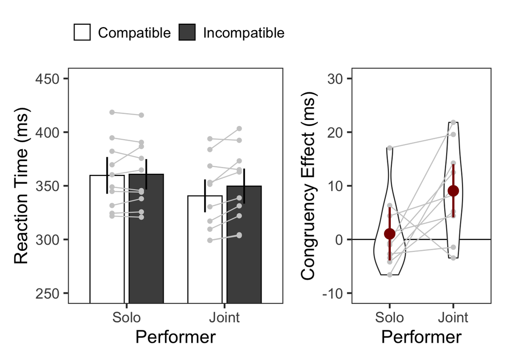

```r
# 2x2 factorial plot
cS1wsci <- cS1slong %>%
  wsci(id = "sid",
       factors = c("performer", "compatibility"),
       dv = "rt") %>%
  rename("wsci" = "rt")

cS1mean <- cS1slong %>% group_by(performer, compatibility) %>%
  summarise(rt = mean(rt)) %>%
  ungroup()

cS1g <- merge(cS1mean, cS1wsci, by = c("performer", "compatibility"), all = TRUE)

cS1swide <- cS1slong %>%  # wide format, needed for geom_segments.
  pivot_wider(id_cols='sid', names_from=c('performer', 'compatibility'), values_from='rt' )

G1 <- ggplot() +
  geom_bar(data=cS1g, aes(x=performer, y=rt, fill=compatibility),
           stat="identity", width=0.7, color="black", position=position_dodge(.8)) +
  geom_linerange(data=cS1g, aes(x=performer, ymin=rt-wsci, ymax=rt+wsci, group=compatibility),
                 size=0.8, position=position_dodge(0.8)) +
  scale_fill_manual(values=c('gray100','gray30'), # 회색조
                    labels=c("Compatible", "Incompatible")) +
  # scale_fill_manual(values=c('#0073C2FF','#EFC000FF'), # 파란-노랑
  #                   labels=c("Compatible", "Incompatible")) +
  geom_point(data=cS1slong, aes(x=performer, y=rt, group=compatibility),
             position=position_dodge(0.6), color="gray80", size=1.8) +
  geom_segment(data=cS1swide, aes(x=1-.15, y=Solo_Compatible,
                                  xend=1+.15, yend=Solo_Incompatible), color="gray80") +
  geom_segment(data=cS1swide, aes(x=2-.15, y=Joint_Compatible,
                                  xend=2+.15, yend=Joint_Incompatible), color="gray80") +
  labs(x = "Performer", y = "Reaction Time (ms)") +
  coord_cartesian(ylim = c(250, 450), clip = "on") +
  theme_bw(base_size = 18) +
  theme(legend.position="top",
        legend.spacing.x = unit(0.5, 'lines'),
        legend.title = element_blank(),
        legend.background = element_blank(),
        panel.grid.major = element_blank(),
        panel.grid.minor = element_blank())


# compatibility effect
cS1CEswide <- cS1swide %>%
  mutate(Solo = Solo_Incompatible - Solo_Compatible,
         Joint = Joint_Incompatible - Joint_Compatible) %>%
  select(sid, Solo, Joint)

cS1CEslong <- cS1CEswide %>%
  pivot_longer(cols = c('Solo', 'Joint'),
               names_to = 'performer',
               values_to = 'ce')
cS1CEslong$performer <- factor(cS1CEslong$performer, levels=c("Solo", "Joint"))

cS1CEmean <- cS1CEslong %>% group_by(performer) %>%
  summarise(ce = mean(ce)) %>%
  ungroup()

cS1CEwsci <- cS1CEslong %>% # wsci - Morey
  wsci(id = "sid",
       factors = c("performer"),
       dv = "ce") %>%
  rename("wsci" = "ce")

cS1CEg <- merge(cS1CEmean, cS1CEwsci, by = c("performer"), all = TRUE)

G2 <- ggplot(cS1CEslong, aes(x=performer, y=ce)) +
  geom_hline(yintercept = 0) +
  geom_violin(width = 0.5, trim=TRUE) +
  geom_point(color="gray80", size=1.8) +
  geom_segment(data=cS1CEswide, color="gray80",
               aes(x=1, y=Solo, xend=2, yend=Joint)) +
  geom_pointrange(cS1CEg, inherit.aes=FALSE,
                  mapping=aes(x = performer, y=ce,
                              ymin = ce - wsci, ymax = ce + wsci),
                  colour="darkred", size = 1) +
  labs(x = "Performer", y = "Congruency Effect (ms)") +
  coord_cartesian(ylim = c(-10, 30), clip = "on") +
  scale_y_continuous(breaks=c(-10, 0, 10, 20, 30)) +
  theme_bw(base_size = 18) +
  theme(panel.grid.major = element_blank(),
        panel.grid.minor = element_blank())

# Multipanel plot
G1 + G2 + plot_layout(nrow = 1, widths = c(2, 1.3))
```

### 2.2.3 Normality Test

반응시간 평균의 분포가 정규분포를 이루는지 검증하였다.

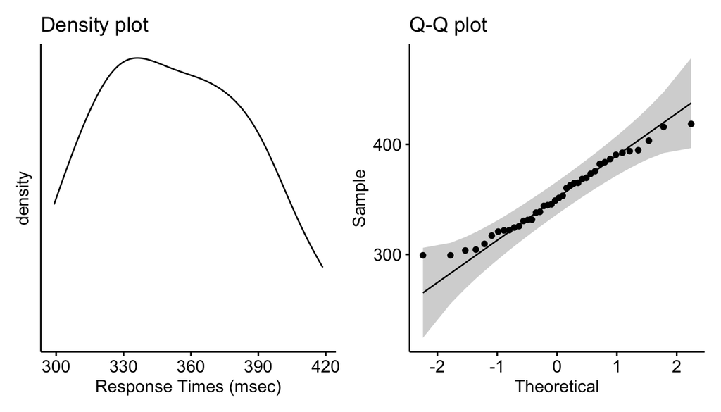

```r
# normality test
N1 <- ggpubr::ggdensity(cS1slong$rt,
                        main = "Density plot",
                        xlab = "Response Times (msec)") +
    theme(axis.text.y = element_blank(),
                axis.ticks.y = element_blank())
N2 <- ggpubr::ggqqplot(cS1slong$rt,
                       main = "Q-Q plot")
N1 + N2 + plot_layout(nrow = 1, widths = c(1, 1))
```

```r
shapiro.test(cS1slong$rt) # 만족

    Shapiro-Wilk normality test

data:  cS1slong$rt
W = 0.96988, p-value = 0.3567
```

정규분포 가정에 위배되지 않으므로 ANOVA를 실시할 수 있다.

### 2.2.4 ANOVA

```r
cS1.aov <- cS1slong %>% aov_ez(id = "sid", dv = "rt", within = c("performer", "compatibility"))
cS1.aov %>% anova(es = "pes") %>%
  kable(digits = 4, caption = "2x2 ANOVA table")
```

2x2 ANOVA table

|  | num Df | den Df | MSE | F | pes | Pr(>F) |
| --- | --- | --- | --- | --- | --- | --- |
| performer | 1 | 9 | 1402.4343 | 1.6185 | 0.1524 | 0.2352 |
| compatibility | 1 | 9 | 33.6637 | 7.6074 | 0.4581 | 0.0222 |
| performer:compatibility | 1 | 9 | 24.0489 | 6.6972 | 0.4266 | 0.0293 |

```r
# afex_plot(cS1.aov, x = "performer", trace = "compatibility")

cS1slong %>% filter(performer == 'Solo') %>%
  aov_ez(id = 'sid', dv = 'rt', within = 'compatibility') %>%
  anova(es = "pes") %>%
  kable(digits = 4, caption = "Congruency effect in the Solo condition")
```

Congruency effect in the Solo condition

|  | num Df | den Df | MSE | F | pes | Pr(>F) |
| --- | --- | --- | --- | --- | --- | --- |
| compatibility | 1 | 9 | 23.4708 | 0.2337 | 0.0253 | 0.6404 |

```r
cS1slong %>% filter(performer == 'Joint') %>%
  aov_ez(id = 'sid', dv = 'rt', within = 'compatibility') %>%
  anova(es = "pes") %>%
  kable(digits = 4, caption = "Congruency effect in the Joint condition")
```

Congruency effect in the Joint condition

|  | num Df | den Df | MSE | F | pes | Pr(>F) |
| --- | --- | --- | --- | --- | --- | --- |
| compatibility | 1 | 9 | 34.2418 | 12.0224 | 0.5719 | 0.0071 |

### 2.2.5 Permutation Test

**본실험**의 자료는 정규성 가정에 위배된 경우가 있었다. 따라서 치환검정을 모든 분석에 적용하기로 한다.

```r
# two-way permutation anova
cS1.2wayperm <- aovperm(rt ~ performer * compatibility + Error(sid/(performer*compatibility)),
                        data = cS1slong, np = nsims)
summary(cS1.2wayperm) %>%
    kable(digits = 4, caption = "Nonparametric ANOVA")
```

Nonparametric ANOVA

|  | SSn | dfn | SSd | dfd | MSEn | MSEd | F | parametric P(>F) | resampled P(>F) |
| --- | --- | --- | --- | --- | --- | --- | --- | --- | --- |
| performer | 2269.8938 | 1 | 12621.9084 | 9 | 2269.8938 | 1402.4343 | 1.6185 | 0.2352 | 0.2411 |
| compatibility | 256.0934 | 1 | 302.9733 | 9 | 256.0934 | 33.6637 | 7.6074 | 0.0222 | 0.0241 |
| performer:compatibility | 161.0594 | 1 | 216.4402 | 9 | 161.0594 | 24.0489 | 6.6972 | 0.0293 | 0.0313 |

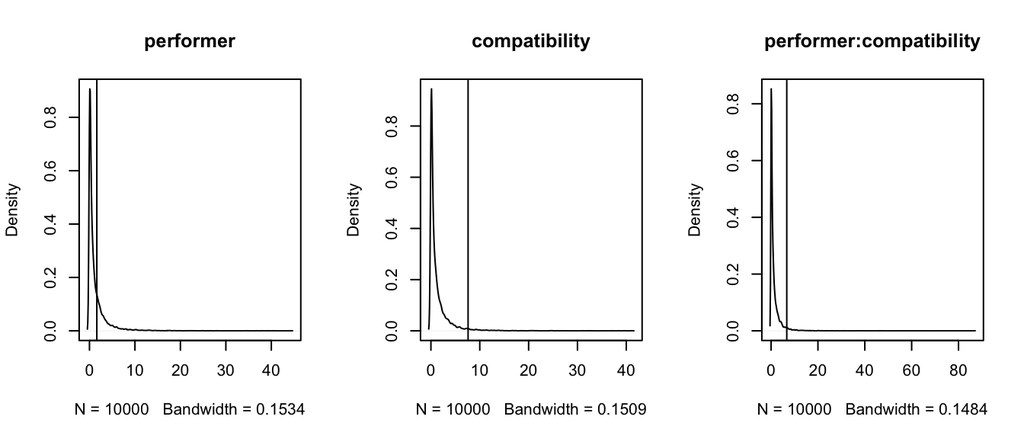

```r
plot(cS1.2wayperm, effect = c("performer",
                                                            "compatibility",
                                                            "performer:compatibility"))
```

`compatibility` 주효과와 `performer:compatibility` 상호작용이 유의미하였다.  
조건별 일치효과가 0보다 큰지 확인하였다.

```r
cS1Solo.1wayperm <- aovperm(rt ~ compatibility + Error(sid/(compatibility)),
                        data = filter(cS1slong, performer=='Solo'), np = nsims)
summary(cS1Solo.1wayperm) %>%
    kable(digits = 4, caption = "Nonparametric simple test")
```

Nonparametric simple test

|  | SSn | dfn | SSd | dfd | MSEn | MSEd | F | parametric P(>F) | resampled P(>F) |
| --- | --- | --- | --- | --- | --- | --- | --- | --- | --- |
| compatibility | 5.4847 | 1 | 211.2373 | 9 | 5.4847 | 23.4708 | 0.2337 | 0.6404 | 0.6386 |

```r
cS1Joint.1wayperm <- aovperm(rt ~ compatibility + Error(sid/(compatibility)),
                            data = filter(cS1slong, performer=='Joint'), np = nsims)
summary(cS1Joint.1wayperm) %>%
    kable(digits = 4, caption = "Nonparametric simple test")
```

Nonparametric simple test

|  | SSn | dfn | SSd | dfd | MSEn | MSEd | F | parametric P(>F) | resampled P(>F) |
| --- | --- | --- | --- | --- | --- | --- | --- | --- | --- |
| compatibility | 411.6681 | 1 | 308.1762 | 9 | 411.6681 | 34.2418 | 12.0224 | 0.0071 | 0.0078 |

사후검증을 위해 FDR 절차로 *p*-value를 보정하였다.

```r
tmp <- p.adjust(c(cS1Solo.1wayperm$table$`resampled P(>F)`,
                  cS1Joint.1wayperm$table$`resampled P(>F)`), "fdr")
data.frame(Solo = tmp[1], Joint = tmp[2]) %>%
  kable(align = 'c', digits = 4, caption = "FDR adjusted p-values")
```

FDR adjusted p-values

| Solo | Joint |
| --- | --- |
| 0.6386 | 0.0156 |

일치 효과는 **Solo** 조건에서 유의미하지 않고 **Joint** 조건에서만 유의미하였다.

## 2.3 Power Test

예비실험의 **Joint** 조건의 결과를 활용하여 참가자 수를 추정하였다. **High load** 집단의 **dual** 과제에서만 SE가 관찰되지 않는 이원상호작용을 기대하였다.

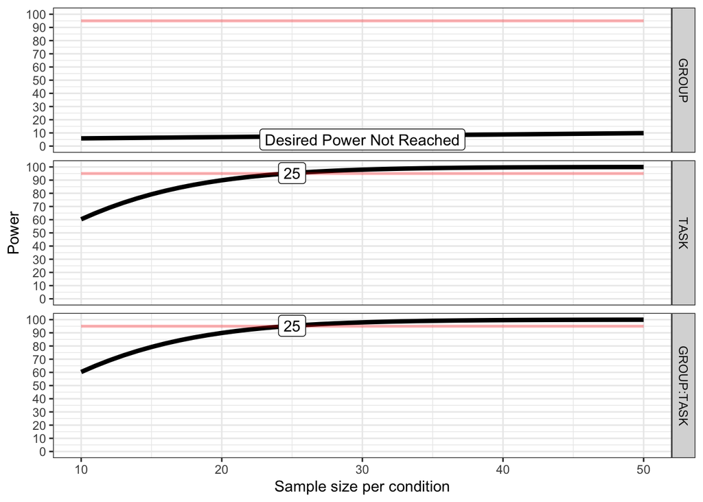

```
Achieved Power and Sample Size for ANOVA-level effects
    variable                     label  n achieved_power desired_power
1      GROUP Desired Power Not Reached 50           9.83            95
2       TASK    Desired Power Achieved 25          95.32            95
3 GROUP:TASK    Desired Power Achieved 25          95.32            95
```

```r
# 조건별 평균
diffM <- cS1 %>%
  group_by(sid, performer, compatibility) %>%
  summarise(M = mean(rt)) %>%
  ungroup() %>%
  group_by(performer, compatibility) %>%
  summarise(RT = mean(M)) %>%
  ungroup() %>%
    filter(performer == "Joint") %>%
    pivot_wider(names_from = compatibility, values_from = RT) %>%
    mutate(RTdiff = Incompatible - Compatible)
as.numeric(diffM$RTdiff)
[1] 9.073787

# 평균 표준편차
pooledSD <- cS1 %>%
  group_by(sid, performer, compatibility) %>%
  summarise(M = mean(rt)) %>%
  ungroup() %>%
  group_by(performer, compatibility) %>%
  summarise(SD = sd(M)) %>%
  ungroup() %>%
    filter(performer == "Joint") %>%
    summarise(pooledSD = mean(SD))
as.numeric(pooledSD)
[1] 34.86426

# 집단별 참가자내 변인의 상관
wcor <- cS1 %>%
  group_by(sid, performer, compatibility) %>%
  summarise(M = mean(rt)) %>%
  ungroup() %>%
    filter(performer == "Joint") %>%
  pivot_wider(names_from = compatibility, values_from = M) %>%
    summarise(wcor = cor(Compatible, Incompatible))
as.numeric(wcor)
[1] 0.9718997

dx0 <- ANOVA_design(
    design = "2b*2w",
    n = 10,
    mu = c(9,9,9,0),
    sd = 35,
    r = 0.97,
    labelnames = c("GROUP", "Lowload", "Highload",
                                 "TASK", "Single", "Dual"),
    plot = FALSE
)

plot_power(dx0,
           min_n = 10, max_n = 50,
           desired_power = 95,
                     plot = TRUE)
```

이원 상호작용 관찰을 위해 각 집단에 최소 25명이 필요하다. 본실험 참가자 수는 8의 배수가 되어야 하므로 **Low load** 집단과 **High load** 집단에 각 32명을 모집하기로 결정하였다.

# 3 Main Experiment

작업기억 부하 효과를 관찰하였다. 한 세션에 두 명의 참가자가 함께 과제를 수행하였다(Fig 1C).

## 3.1 Working Memory Task

### 3.1.1 Descriptive Stats

조건별 작업기억 과제의 정확률은 다음과 같다.

```r
WW <- read.csv('data/mergeJSEv5_WMtask.csv', header = TRUE)
headTail(WW)
##     sid group trial change resp corr   rt
## 1   101   Low     1      1    1    1  0.9
## 2   101   Low     2      1    1    1 0.62
## 3   101   Low     3      1    1    1 0.69
## 4   101   Low     4      2    2    1 1.01
## ... ...  <NA>   ...    ...  ...  ...  ...
## 765 232  High     9      2    2    1 0.71
## 766 232  High    10      1    1    1 0.76
## 767 232  High    11      1    1    1 0.68
## 768 232  High    12      1    1    1 0.42

table(WW$corr, WW$sid)
##
##     101 102 103 104 105 106 107 108 109 110 111 112 113 114 115 116 117 118 119
##   0   1   0   0   0   0   0   0   1   0   4   1   0   3   1   0   0   1   0   0
##   1  11  12  12  12  12  12  12  11  12   8  11  12   9  11  12  12  11  12  12
##
##     120 121 122 123 124 125 126 127 128 129 130 131 132 201 202 203 204 205 206
##   0   0   0   1   1   0   0   0   1   1   3   0   1   3   1   1   6   1   1   1
##   1  12  12  11  11  12  12  12  11  11   9  12  11   9  11  11   6  11  11  11
##
##     207 208 209 210 211 212 213 214 215 216 217 218 219 220 221 222 223 224 225
##   0   3   0   0   1   0   0   0   0   1   1   0   1   1   4   1   1   3   0   0
##   1   9  12  12  11  12  12  12  12  11  11  12  11  11   8  11  11   9  12  12
##
##     226 227 228 229 230 231 232
##   0   3   3   3   1   3   0   1
##   1   9   9   9  11   9  12  11
WW <- WW %>% mutate(group = factor(group, levels = c('Low', 'High')))
WW$rt <- WW$rt*1000

# 참가자 수
WW %>% group_by(group) %>%
  summarise(count = n_distinct(sid)) %>%
  ungroup()
## # A tibble: 2 × 2
##   group count
##   <fct> <int>
## 1 Low      32
## 2 High     32

# WM RT
rWW <- WW %>% filter(corr == 1) %>%
  group_by(sid, group) %>%
  nest() %>%
  mutate(lbound = map(data, ~mean(.$rt)-3*sd(.$rt)), # lower/upper bound 계산
         ubound = map(data, ~mean(.$rt)+3*sd(.$rt))) %>%
  unnest(c(lbound, ubound)) %>%
  unnest(data) %>%
  mutate(outlier = (rt < lbound)|(rt > ubound)) %>%
  filter(outlier == FALSE) %>%
  ungroup() %>%
  select(sid, group, rt)

(nrow(WW)-nrow(rWW))*100/nrow(WW)
## [1] 8.463542

aWWsum <- WW %>% group_by(group, sid) %>%
  summarise(MN = mean(corr)*100) %>%
  ungroup() %>%
  group_by(group) %>%
  summarise(N = n(),
                        Mean = mean(MN),
            SD = sd(MN)) %>%
  ungroup()

aWWsum %>%
  kable(digits = 4, caption = "Descriptive statistics: WM accuracy")
```

Descriptive statistics: WM accuracy

| group | N | Mean | SD |
| --- | --- | --- | --- |
| Low | 32 | 94.0104 | 9.0385 |
| High | 32 | 89.0625 | 12.0553 |

평균으로부터 3SD 떨어진 반응시간 8.4635%를 제거한 후, 집단별 작업기억 과제의 반응시간은 다음과 같다.

```r
rWWsum <- rWW %>% group_by(group, sid) %>%
    summarise(MN = mean(rt)) %>%
    ungroup() %>%
    group_by(group) %>%
    summarise(N = n(),
                        Mean = mean(MN),
                        SD = sd(MN)) %>%
    ungroup()

rWWsum %>%
    kable(digits = 4, caption = "Descriptive statistics: WM RT")
```

Descriptive statistics: WM RT

| group | N | Mean | SD |
| --- | --- | --- | --- |
| Low | 32 | 956.7012 | 153.3393 |
| High | 32 | 1134.0039 | 207.9728 |

### 3.1.2 Plots

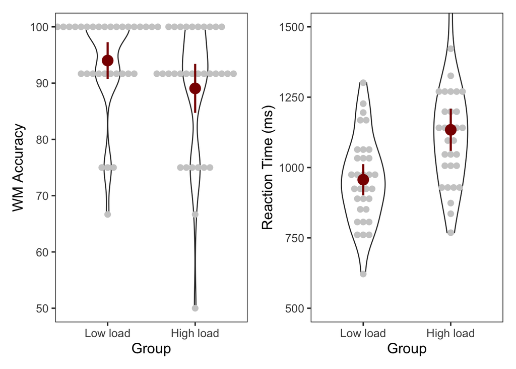

```r
aWWslong <- WW %>% group_by(sid, group) %>%
  summarise(acc = mean(corr)*100) %>%
  ungroup()

WG1 <- ggplot(aWWslong, aes(x=group, y=acc)) +
  geom_violin(width = 0.5, trim = TRUE) +
  geom_dotplot(binaxis='y', stackdir='center', dotsize=.7,
               color='gray80', fill='gray80', binwidth=1.5) +
  stat_summary(fun.data = mean_cl_normal, geom="pointrange", color="darkred", size=1) +
  labs(x="Group", y="WM Accuracy") +
  scale_x_discrete(labels=c("Low load", "High load")) +
  coord_cartesian(ylim=c(50, 100)) +
  theme_bw(base_size = 14) +
  theme(panel.grid.major = element_blank(),
        panel.grid.minor = element_blank(),
        plot.title = element_text(hjust = .5))

# WM RT
rWWslong <- rWW %>% group_by(sid, group) %>%
  summarise(rt = mean(rt)) %>%
  ungroup()

WG2 <- ggplot(rWWslong, aes(x=group, y=rt)) +
  geom_violin(width = 0.5, trim = TRUE) +
  geom_dotplot(binaxis='y', stackdir='center', dotsize=.7,
               color='gray80', fill='gray80', binwidth=30) +
  stat_summary(fun.data = mean_cl_normal, geom="pointrange", color="darkred", size=1) +
  labs(x="Group", y="Reaction Time (ms)") +
  scale_x_discrete(labels=c("Low load", "High load")) +
  coord_cartesian(ylim=c(500, 1500)) +
  theme_bw(base_size = 14) +
  theme(panel.grid.major = element_blank(),
        panel.grid.minor = element_blank(),
        plot.title = element_text(hjust = .5))

# Multipanel plot
WG1 + WG2
```